# Impact of Federal Reserve Rate Cuts on Economic Indicators

## Project Overview

This project explores the impact of the Federal Reserve’s interest rate cuts in March 2020 and September 2024 on key economic indicators, including the NASDAQ Composite, Unemployment Rate, Inflation, and the 10-Year Treasury Yield. By analyzing these indicators through statistical methods and visualizations, we aim to understand how distinct economic contexts—crisis-driven in 2020 versus proactive support in 2024—influence market responses and the broader economy. This analysis sheds light on the nuanced role of monetary policy, revealing how rate cuts can drive investor sentiment, shape employment trends, and impact inflation under varying conditions.

# Importing Libraries

```python
%pip install -q pandas
%pip install -q nbformat
%pip install -q statsmodels
%pip install -q matplotlib
%pip install -q plotly
%pip install -q numpy
%pip install -q seaborn
```

```python
import pandas as pd
import numpy as np
import datetime
import random
import warnings
import seaborn as sns
import scipy.stats as stats
import matplotlib.pyplot as plt
import matplotlib.dates as mdates
from datetime import timedelta
```

```python
warnings.filterwarnings(
    "ignore",
    message="X does not have valid feature names, but RandomForestRegressor was fitted with feature names"
)
```

# Gathering Data

```python
treasury_data = pd.read_csv('Data/10YrTsy.csv')
nasdaq_data = pd.read_csv('Data/NasdaqData.csv')
gdp_data = pd.read_csv('Data/GDP.csv')
inflation_data = pd.read_csv('Data/Inflation.csv')
unemployment_data = pd.read_csv('Data/Unemployment.csv')
fed_rates_data = pd.read_csv('Data/FedRates.csv')
```

```python
treasury_data.rename(columns = {'DGS10':'10YrTsy'}, inplace = True)
nasdaq_data.rename(columns = {'Close':'NASDAQ Composite'}, inplace = True)
unemployment_data.rename(columns = {'UNRATE':'UnemploymentRate'}, inplace = True)
inflation_data.rename(columns = {'T10YIE':'Inflation'}, inplace = True)
gdp_data.rename(columns = {'GDPC1':'GDP'}, inplace = True)
fed_rates_data.rename(columns = {'FEDFUNDS':'FFR'}, inplace = True)
```

```python
data = pd.merge(treasury_data, nasdaq_data, on='DATE', how='right')
data = pd.merge(data, gdp_data, on='DATE', how='left')
data = pd.merge(data, inflation_data, on='DATE', how='left')
data = pd.merge(data, unemployment_data, on='DATE', how='left')
data = pd.merge(data, fed_rates_data, on='DATE', how='left')

data = data.sort_values(by='DATE')
data['DATE'] = pd.to_datetime(data['DATE'], format='%Y-%m-%d')
data
```

|  | DATE | 10YrTsy | NASDAQ Composite | GDP | Inflation | UnemploymentRate | FFR |
| --- | --- | --- | --- | --- | --- | --- | --- |
| 0 | 1971-02-05 | 6.10 | 100.00 | NaN | NaN | NaN | NaN |
| 1 | 1971-02-06 | NaN | 100.84 | NaN | NaN | NaN | NaN |
| 2 | 1971-02-07 | NaN | 100.84 | NaN | NaN | NaN | NaN |
| 3 | 1971-02-08 | 6.09 | 100.84 | NaN | NaN | NaN | NaN |
| 4 | 1971-02-09 | 6.07 | 100.76 | NaN | NaN | NaN | NaN |
| ... | ... | ... | ... | ... | ... | ... | ... |
| 19601 | 2024-10-05 | NaN | 18137.85 | NaN | NaN | NaN | NaN |
| 19602 | 2024-10-06 | NaN | 18137.85 | NaN | NaN | NaN | NaN |
| 19603 | 2024-10-07 | 4.03 | 17923.90 | NaN | 2.27 | NaN | NaN |
| 19604 | 2024-10-08 | 4.04 | 18182.92 | NaN | 2.27 | NaN | NaN |
| 19605 | 2024-10-09 | NaN | 18291.62 | NaN | 2.29 | NaN | NaN |

19606 rows × 7 columns

# Data Cleaning

```python
data.describe()
```

|  | DATE | NASDAQ Composite | GDP | UnemploymentRate | FFR |
| --- | --- | --- | --- | --- | --- |
| count | 19606 | 18809.000000 | 213.000000 | 644.000000 | 643.000000 |
| mean | 1997-12-07 12:00:00 | 2787.836347 | 10380.074601 | 6.115839 | 4.873421 |
| min | 1971-02-05 00:00:00 | 54.870000 | 1156.271000 | 3.400000 | 0.050000 |
| 25% | 1984-07-07 06:00:00 | 280.300000 | 4084.250000 | 4.900000 | 1.415000 |
| 50% | 1997-12-07 12:00:00 | 1384.850000 | 8765.907000 | 5.800000 | 5.020000 |
| 75% | 2011-05-09 18:00:00 | 3010.600000 | 15351.448000 | 7.200000 | 6.810000 |
| max | 2024-10-09 00:00:00 | 18647.450000 | 29016.714000 | 14.800000 | 19.100000 |
| std | NaN | 3869.583090 | 7333.352008 | 1.721738 | 3.912594 |

```python
data.dtypes
```

```
DATE                datetime64[ns]
10YrTsy                     object
NASDAQ Composite           float64
GDP                        float64
Inflation                   object
UnemploymentRate           float64
FFR                        float64
dtype: object
```

```python
data['10YrTsy'] = pd.to_numeric(data['10YrTsy'], errors='coerce')
data['Inflation'] = pd.to_numeric(data['Inflation'], errors='coerce')
data.dtypes
```

```
DATE                datetime64[ns]
10YrTsy                    float64
NASDAQ Composite           float64
GDP                        float64
Inflation                  float64
UnemploymentRate           float64
FFR                        float64
dtype: object
```

```python
data['DATE'] = pd.to_datetime(data['DATE'], format='%Y-%m-%d')
data = data[data['DATE'] >= pd.to_datetime('2014-12-31')]
data = data.ffill()
data = data.iloc[1:]
data.set_index("DATE", inplace = True)
data
```

| DATE | 10YrTsy | NASDAQ Composite | GDP | Inflation | UnemploymentRate | FFR |
| --- | --- | --- | --- | --- | --- | --- |
| 2015-01-01 | 2.17 | 4736.05 | 18063.529 | 1.68 | 5.7 | 0.11 |
| 2015-01-02 | 2.12 | 4726.81 | 18063.529 | 1.71 | 5.7 | 0.11 |
| 2015-01-03 | 2.12 | 4652.57 | 18063.529 | 1.71 | 5.7 | 0.11 |
| 2015-01-04 | 2.12 | 4652.57 | 18063.529 | 1.71 | 5.7 | 0.11 |
| 2015-01-05 | 2.04 | 4652.57 | 18063.529 | 1.64 | 5.7 | 0.11 |
| ... | ... | ... | ... | ... | ... | ... |
| 2024-10-05 | 3.98 | 18137.85 | 29016.714 | 2.23 | 4.0 | 5.13 |
| 2024-10-06 | 3.98 | 18137.85 | 29016.714 | 2.23 | 4.0 | 5.13 |
| 2024-10-07 | 4.03 | 17923.90 | 29016.714 | 2.27 | 4.0 | 5.13 |
| 2024-10-08 | 4.04 | 18182.92 | 29016.714 | 2.27 | 4.0 | 5.13 |
| 2024-10-09 | 4.04 | 18291.62 | 29016.714 | 2.29 | 4.0 | 5.13 |

3570 rows × 6 columns

```python
data.isnull().sum()
```

```
10YrTsy             0
NASDAQ Composite    0
GDP                 0
Inflation           0
UnemploymentRate    0
FFR                 0
dtype: int64
```

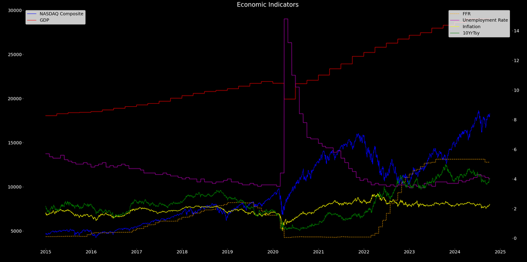

```python
fig, ax1 = plt.subplots(figsize=(30, 15))
ax1.set_facecolor('black')
ax2 = ax1.twinx()
ax2.set_facecolor('black')

ax1.plot(data.index, data['NASDAQ Composite'], label='NASDAQ Composite', color='b')
ax1.plot(data.index, data['GDP'], label='GDP', color='r')
ax1.set_xlabel('Date', fontsize=20)
ax1.set_ylabel('Economic Indicators', fontsize=20)

ax2.plot(data.index, data['FFR'], label='FFR', color='orange', linestyle='--')
ax2.plot(data.index, data['UnemploymentRate'], label='Unemployment Rate', color='m')
ax2.plot(data.index, data['Inflation'], label='Inflation', color='yellow')
ax2.plot(data.index, data['10YrTsy'], label='10YrTsy', color='g')
ax2.set_ylabel('Economic Indicators', fontsize=20)

ax1.tick_params(axis='x', colors='white', labelsize=18)
ax1.tick_params(axis='y', colors='white', labelsize=18)
ax2.tick_params(axis='y', colors='white', labelsize=18)

ax1.legend(loc='upper left', fontsize=18)
ax2.legend(loc='upper right', fontsize=18)

plt.title('Economic Indicators', fontsize=25, color='white')
plt.xticks(rotation=45, color='white')
plt.gcf().set_facecolor('black')

plt.tight_layout()
plt.show()
```

# Analysis

The Federal Reserve implemented rate cuts in response to different economic conditions: a drastic cut of 150 basis points on March 16, 2020, due to the COVID-19 pandemic, and a more moderate cut of 50 basis points on September 18, 2024, to support ongoing economic growth. By examining key economic indicators—NASDAQ Composite, Unemployment Rate, Inflation, 10-Year Treasury Yield, and GDP—around these dates, we can observe how the market responded differently to these cuts under contrasting circumstances.

```python
rate_cut_date_2020 = pd.to_datetime('2020-03-16')
rate_cut_date_2024 = pd.to_datetime('2024-09-18')

window_days = 15
pre_2020 = data[(data.index >= rate_cut_date_2020 - pd.Timedelta(days=window_days)) &
                (data.index < rate_cut_date_2020)]
post_2020 = data[(data.index > rate_cut_date_2020) &
                 (data.index <= rate_cut_date_2020 + pd.Timedelta(days=window_days))]

pre_2024 = data[(data.index >= rate_cut_date_2024 - pd.Timedelta(days=window_days)) &
                (data.index < rate_cut_date_2024)]
post_2024 = data[(data.index > rate_cut_date_2024) &
                 (data.index <= rate_cut_date_2024 + pd.Timedelta(days=window_days))]
```